# The internal structure of crystals

Dr. Ahmad Redaa

2024-09-09

# Recap

- **Minerals:** a substance must meet the following criteria to be classified as a mineral:
  1. Naturally occurring: Formed by natural processes without human intervention.
  2. Inorganic: Not produced by biological processes.
  3. Solid: Must exist in a solid state under normal Earth conditions.
  4. Definite chemical composition: Has a specific chemical formula.
  5. Crystalline structure: Atoms are arranged in an orderly and repeating pattern.
- **What are atoms?**

# Atomic Structure

- **Atom**: The basic unit of matter, consisting of a nucleus surrounded by electrons.
- **Nucleus**: The atom’s core, containing protons and neutrons.
- **Electrons**: Negatively charged particles orbiting the nucleus in electron shells.

[figure not shown]

# Electron Configuration

- **Electron Configuration**: Determines bonding and properties
- **Example**: Silicon in quartz - **[Ne] 3s² 3p²**

# Bonding Forces in Crystals (1)

- **Ionic Bond**
  - Ionic bonds form, for example, between **sodium (Na)** and **chlorine (Cl)** in **NaCl**.
  - **Electrons are transferred** from sodium to chlorine.
  - This transfer creates **positively charged sodium ions (Na⁺)** and **negatively charged chloride ions (Cl⁻)**.
  - The **electrostatic attraction** between Na⁺ and Cl⁻ holds the compound together.
  - Key properties of ionic compounds:
    - **High melting and boiling points** (due to strong ionic bonds).
    - **Electrical conductivity** when molten or dissolved (ions are free to move).

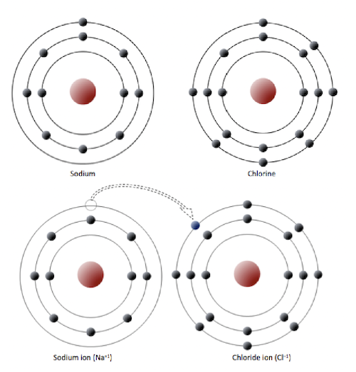

Source: [Steven, E. (2015)](https://openlibrary-repo.ecampusontario.ca/jspui/handle/123456789/402)

# Bonding Forces in Crystals (2)

- **Covalent Bond**
  - Covalent bonds involve the **sharing of electrons** between atoms.
  - In **diamond (C)**, each carbon atom shares **four electrons** with other carbon atoms.
  - This creates a **strong, three-dimensional network** of covalently bonded carbon atoms.
  - Key properties of covalent compounds:
    - **High hardness and melting point** (due to strong covalent bonds in the structure).
    - **Non-conductive** (no free electrons to carry an electrical charge).

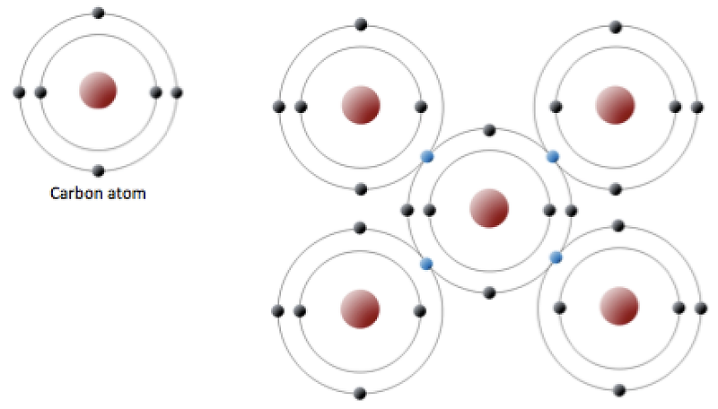

Source: [https://www.uyir.at](https://www.uyir.at/explore-learn/aryan/diamond-structure)

# Bonding Forces in Crystals (3)

- **Metallic Bond**
  - Metallic elements have **loosely held outer electrons**.
  - **Free movement of electrons** occurs when bonds form between metal atoms.
  - **Formation**: Delocalized electron sea
  - This structure explains two key properties of metals:
    - **Electrical conductivity** (free electrons allow current to flow).
    - **Malleability** (metals can be deformed and shaped easily).
  - **Example**: Copper (Cu)

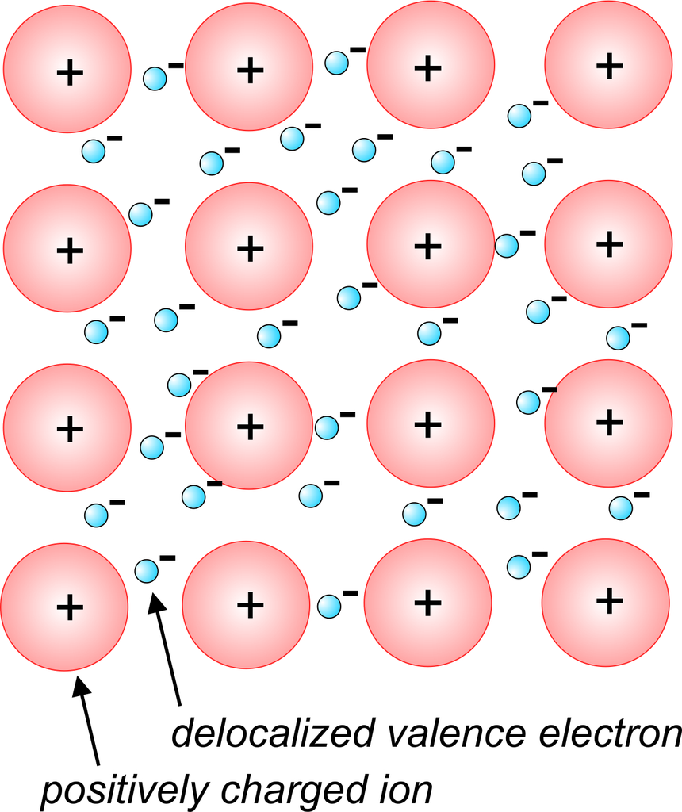

Source: https://geo.libretexts.org/

# Bonding Forces in Crystals (4)

- **Van der Waals Bond**
  - the bond is a weak, non-covalent interaction between molecules or within parts of a molecule, arising from temporary dipoles or induced charges.
  - **Graphite** consists of layers of carbon atoms bonded covalently within each layer.
  - Between these layers, **Van der Waals forces** hold the layers together.
  - These are **weak attractions** caused by temporary dipoles between adjacent layers.
  - This structure gives graphite its unique properties:
    - **Slippery and soft** (layers can easily slide over each other).
    - **Good electrical conductor** (electrons can move freely within layers).

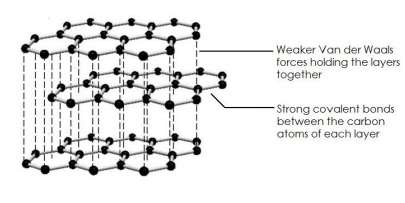

Source: [Poulla, Kalotina. (2019)](https://www.researchgate.net/publication/340485721_Green_reduction_of_Graphene_Oxide_using_Biocompatible_methods?channel=doi&linkId=5e8c780d92851c2f5286c490&showFulltext=true)

# Diamond vs Graphite

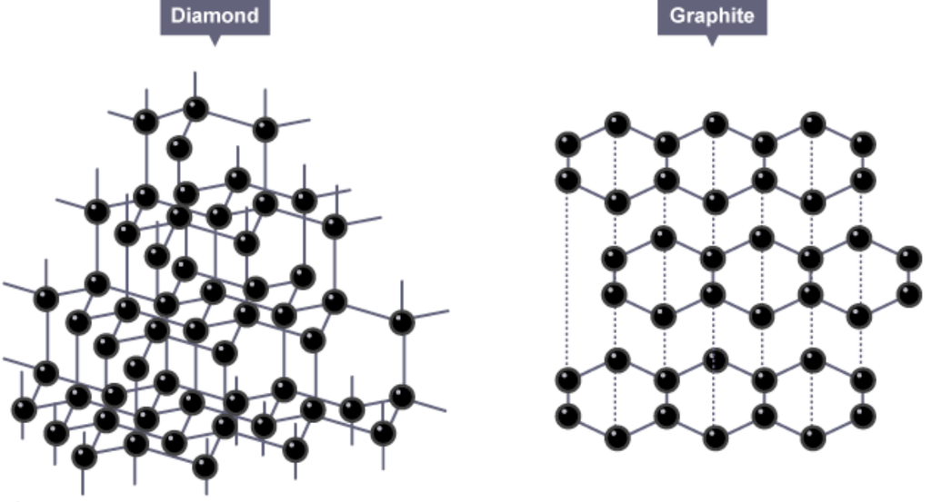

Source: [https://www.toppr.com](https://www.toppr.com/ask/question/compare-the-structures-of-diamond-and-graphite/)

# Unit Cell, Crystal Lattice, and Coordination Number

- **Unit Cell**:  
  The smallest repeating structure in a crystal. It contains atoms arranged in a specific pattern and, when repeated, forms the entire crystal.
- **Crystal Lattice**:  
  A 3D arrangement of unit cells that repeat in space. It defines the overall symmetry and physical properties of the crystal.
- **Coordination Number**:  
  The number of nearest neighboring atoms surrounding a central atom in a crystal structure. It reflects the density and arrangement of atoms in the crystal lattice.
- **Key concept**:  
  Crystals are composed of unit cells that repeat in space, forming a crystal lattice, with coordination number determining atomic packing.

[figure not shown]

Source: [https://www.britannica.com](https://www.britannica.com/science/mineral-chemical-compound/Silicates)

# Example

- Silicate Minerals**:  
  The silicon-oxygen (SiO₄)⁴⁻ tetrahedron is the fundamental building block of silicate minerals. The tetrahedra can link in various ways to form silicate subgroups:
  - **Isolated tetrahedra** (e.g., **Olivine**)
  - **Single chains** (e.g., **Pyroxenes**)
  - **Double chains** (e.g., **Amphiboles**)
  - **Sheet structures** (e.g., **Micas**)

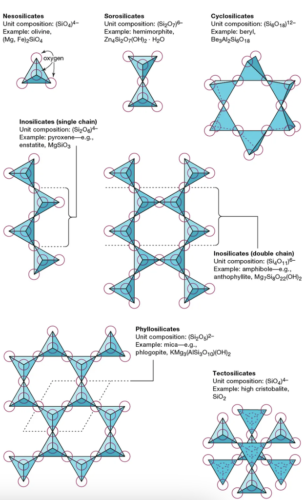

Source: [https://www.britannica.com](https://www.britannica.com/science/mineral-chemical-compound/Silicates)

# Check your understanding (1)

1. **Which of the following is NOT a criterion for a substance to be classified as a mineral?**
   - 1. Naturally occurring
   - 2. Inorganic
   - 3. Liquid under normal Earth conditions
   - 4. Crystalline structure

# Check your understanding (2)

2. **What holds the ions together in an ionic bond, such as in NaCl?**
   - 1. Sharing of electrons
   - 2. Electrostatic attraction
   - 3. Van der Waals forces
   - 4. Free movement of electrons

# Check your understanding (3)

3. **Which of the following bonds is characterized by the sharing of electrons between atoms?**
   - 1. Ionic bond
   - 2. Covalent bond
   - 3. Metallic bond
   - 4. Van der Waals bond

# Check your understanding (4)

4. **What is the coordination number in a crystal structure?**
   - 1. The number of unit cells in the crystal lattice
   - 2. The number of nearest neighboring atoms surrounding a central atom
   - 3. The number of free electrons in a metal
   - 4. The number of atoms in a silicate tetrahedron

# Check your understanding (5)

5. **Which property of graphite is due to Van der Waals forces between its layers?**
   - 1. High hardness
   - 2. Electrical conductivity
   - 3. Slippery and soft texture
   - 4. High melting point